#### Ce que mesure l’indice

L’Indice Planète Vivante (IPV) mesure la tendance globale de l’abondance des vertébrés dans les systèmes terrestres, d’eau douce et marins depuis 1990. L’indice mesure une moyenne de tendances de taux de croissances des populations, et non des changements dans le nombre total d’animaux ou d’espèces au Québec.

Une valeur **entre 0 et 1** indiquerait qu’en moyenne, les populations animales sont en déclin, où 0 signifierait que les populations suivies ont diminué à 0% de leur taille en 1990 et donc se sont éteints et une valeur de 0.99 signifierait que les populations ont subit un déclin de 1% de leur abondance depuis 1990. Une **valeur de 1** indiquerait que les populations animales sont en moyenne stables, donc qu’elles maintiennent (en moyenne) la même abondance depuis 1990. Une **valeur plus grande que 1** indiquerait que les populations sont en moyenne en croissance, donc qu’elles sont plus abondantes comparé à leur taille en 1990.

#### Comment calculer l’indice

L’Indice Planète Vivante a été calculée pour le Québec en suivant [cette méthodologie](https://doi.org/10.1111/j.1523-1739.2008.01117.x), et a été développée par Loh *et al.* (2006) avec le Zoological Society of London et le World Wildlife Fund (WWF). Pour en savoir plus sur l’indice, consultez [ceci](https://livingplanetindex.org/home/index).

### Mises en garde

L’Indice Planète Vivante du Québec ne représente qu’une petite partie de la biodiversité québécoise:

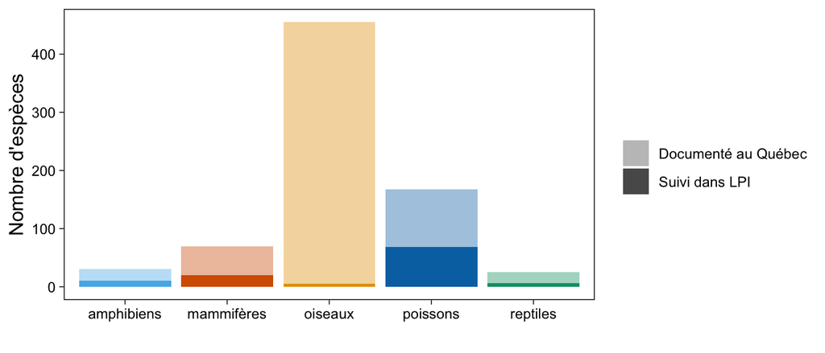